# 4 Species niche

```r
library(grassland)
theme_set(ggthemes::theme_few())
```

Download biogeography (occurrence) data from four sources: BIEN, CCH, GBIF, iNat.

```r
spp_tbl <- tidy_taxonomy_consolidate(dat_community = dat_community)
path_occ <- down_biogeography(species_table = spp_tbl) # needs parallel computation
dat_occ_full <- read_biogeography(path_occ = path_occ, gbif_only = F)
dat_occ <- read_biogeography(path_occ = path_occ, gbif_only = T)
```

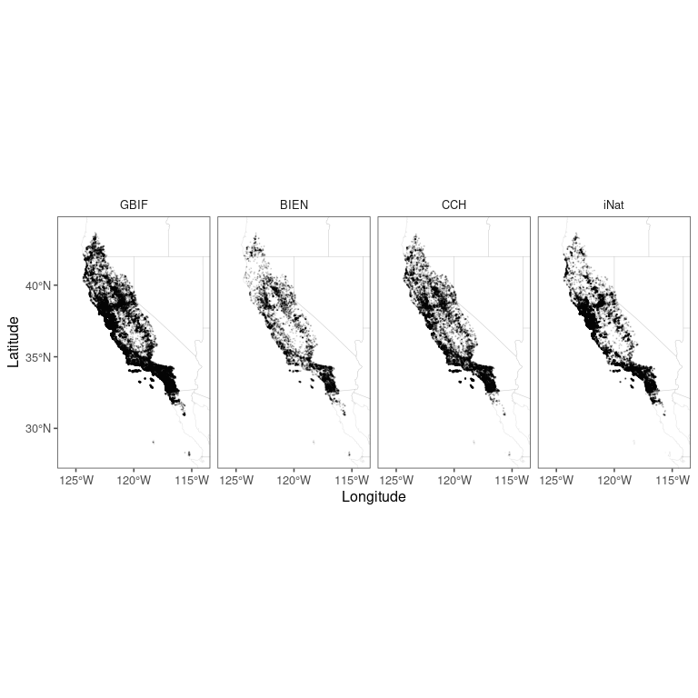

```r
dat_occ_full <- read_biogeography(gbif_only = F)
gg_biogeography <- plot_biogeography(dat_occ_full)
gg_biogeography
```

```r
df_summ_occ <- summ_biogeography(dat_occ = dat_occ_full)
df_summ_occ
```

```
#>   source  n_occ n_sp
#> 1   gbif 830870  374
#> 2   bien 102352  251
#> 3    cch 230903  377
#> 4   inat 552033  350
```

We retrieved 830870 occurrence records of 374 species in the CFP from the Global Biodiversity Information Facility (GBIF).

Calculate and summarize species climate niches.

```r
dat_clim <- read_climate()
path_trait <- calc_individual_trait(dat_occ, dat_clim, occ_source = "gbif", clim_source = "chelsa")
dat_trait <- read_individual_trait(path_trait = path_trait)
```

```r
dat_niche <- calc_species_niche(dat_trait, add_dummy = T)
df_summ_niche <- summ_species_niche(dat_niche = dat_niche)
```

Compare species niches by guilds.

```r
dat_guild_niche <- calc_guild_niche(dat_community, dat_niche)
```

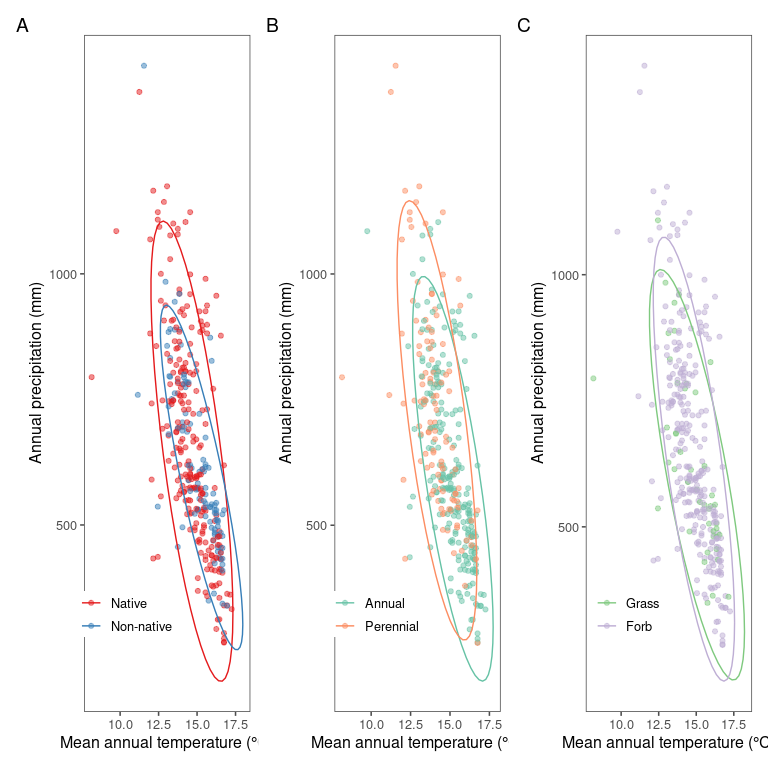

```r
gg_guild_niche <- plot_guild_niche(dat_guild_niche = dat_guild_niche)
gg_guild_niche
```

```r
res_guild_niche <- test_guild_niche(dat_guild_niche = dat_guild_niche)
res_guild_niche
```

```
#> $Origin
#> Permutation test for adonis under reduced model
#> Terms added sequentially (first to last)
#> Permutation: free
#> Number of permutations: 999
#>
#> vegan::adonis2(formula = response ~ guild, data = predict)
#>           Df SumOfSqs      R2      F Pr(>F)
#> guild      1   0.0676 0.00899 3.1567   0.07 .
#> Residual 348   7.4567 0.99101
#> Total    349   7.5243 1.00000
#> ---
#> Signif. codes:  0 '***' 0.001 '**' 0.01 '*' 0.05 '.' 0.1 ' ' 1
#>
#> $`Life history`
#> Permutation test for adonis under reduced model
#> Terms added sequentially (first to last)
#> Permutation: free
#> Number of permutations: 999
#>
#> vegan::adonis2(formula = response ~ guild, data = predict)
#>           Df SumOfSqs      R2      F Pr(>F)
#> guild      1   0.0676 0.00899 3.1567  0.079 .
#> Residual 348   7.4567 0.99101
#> Total    349   7.5243 1.00000
#> ---
#> Signif. codes:  0 '***' 0.001 '**' 0.01 '*' 0.05 '.' 0.1 ' ' 1
#>
#> $`Functional group`
#> Permutation test for adonis under reduced model
#> Terms added sequentially (first to last)
#> Permutation: free
#> Number of permutations: 999
#>
#> vegan::adonis2(formula = response ~ guild, data = predict)
#>           Df SumOfSqs      R2      F Pr(>F)
#> guild      1   0.0676 0.00899 3.1567  0.076 .
#> Residual 348   7.4567 0.99101
#> Total    349   7.5243 1.00000
#> ---
#> Signif. codes:  0 '***' 0.001 '**' 0.01 '*' 0.05 '.' 0.1 ' ' 1
```

Plot and summarize two example species geographic distributions and climate niches.

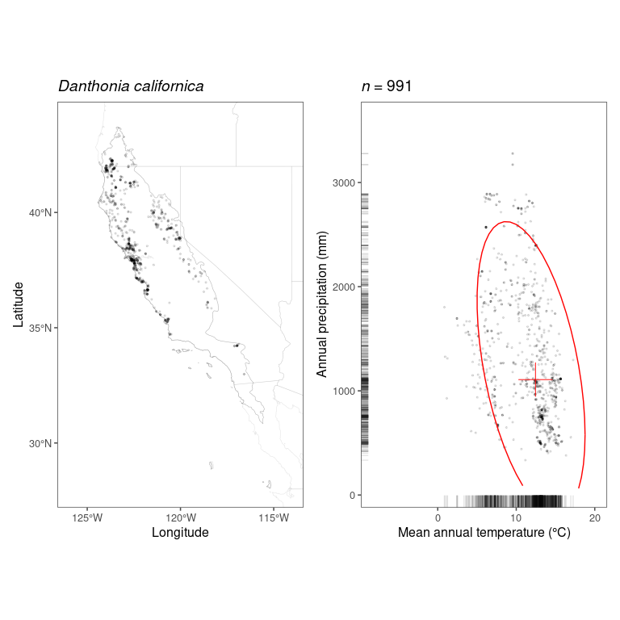

```r
gg_individual_trait_species_niche_cool <- plot_individual_trait_species_niche_ind_sp(dat_occ, dat_trait, sp = "Danthonia californica")
gg_individual_trait_species_niche_cool
```

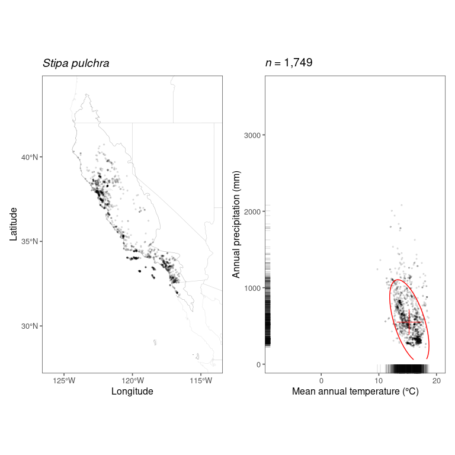

```r
gg_individual_trait_species_niche_warm <- plot_individual_trait_species_niche_ind_sp(dat_occ, dat_trait, sp = "Stipa pulchra")
gg_individual_trait_species_niche_warm
```

```r
df_summ_niche_cool <- summ_species_niche(dat_niche = dat_niche, sp = "Danthonia californica")
df_summ_niche_warm <- summ_species_niche(dat_niche = dat_niche, sp = "Stipa pulchra")
```

*Danthonia californica* had 991 records, with temperature of 12.5 (5.5 -15.3 )°C and precipitation of 1,110 (510-2,750) mm, whereas *Stipa pulchra* had 1749 records, with temperature of 15.3 (12.9 -17.4 )°C and precipitation of 549 (279-1,110) mm.

Plot all species climate niches.

```r
path_gg_trait <- plot_individual_trait_species_niche_ind_sp_all(dat_occ, dat_trait, dat_niche)
```

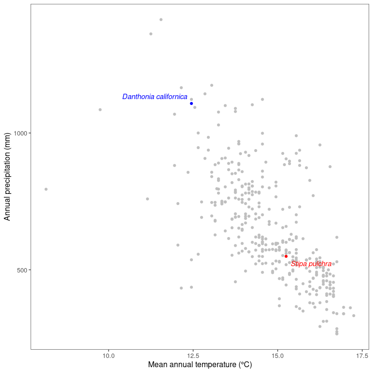

```r
gg_niche <- plot_individual_trait_species_niche_all(dat_occ, dat_trait, dat_niche, frac = 0)
gg_niche$sp_niche
```

Calculate all species climate niches temperature and precipitation correlation.

```r
mod_species_niche_cor <- test_species_niche(dat_niche = dat_niche)
mod_species_niche_cor
```

```
#>
#>  Pearson's product-moment correlation
#>
#> data:  dat_niche$tmp_occ_median and dat_niche$ppt_occ_median
#> t = -16.004, df = 375, p-value < 2.2e-16
#> alternative hypothesis: true correlation is not equal to 0
#> 95 percent confidence interval:
#>  -0.6934349 -0.5729123
#> sample estimates:
#>       cor
#> -0.637051
```

Across all the species, the temperature and precipitation averages were negatively and significantly correlated (Pearson’s correlation *r* = -0.637051).

Compare climate associated with species occurrence from different data sources.

```r
path_trait_chelsa <- calc_individual_trait(dat_occ, dat_clim, occ_source = "gbif", clim_source = "chelsa")
path_trait_prism <- calc_individual_trait(dat_occ, dat_clim, occ_source = "gbif", clim_source = "prism")
path_trait_terraclim <- calc_individual_trait(dat_occ, dat_clim, occ_source = "gbif", clim_source = "terraclim")
```

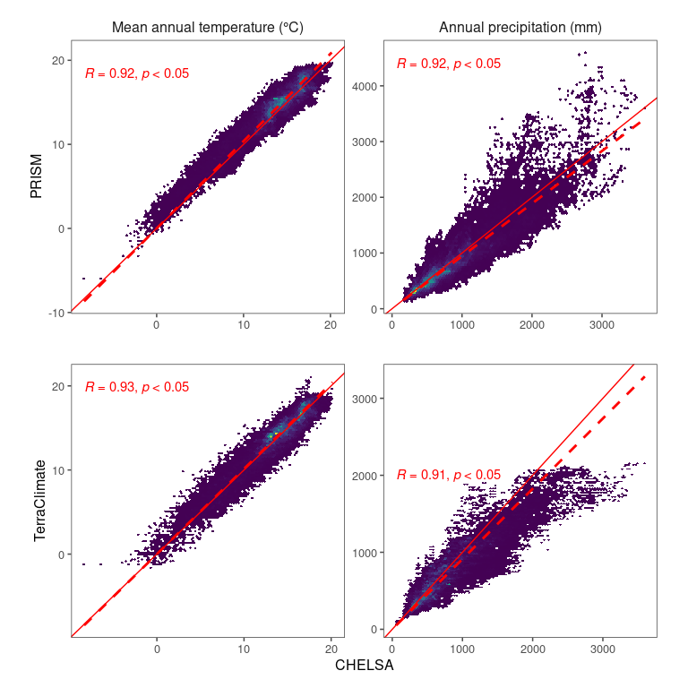

```r
dat_trait_chelsa <- read_individual_trait(path_trait = "alldata/intermediate/climate-niche/gbif-chelsa.rds")
dat_trait_prism <- read_individual_trait(path_trait = "alldata/intermediate/climate-niche/gbif-prism.rds")
dat_trait_terraclim <- read_individual_trait(path_trait = "alldata/intermediate/climate-niche/gbif-terraclim.rds")
gg_climate_source <- plot_climate_source(dat_trait_chelsa, dat_trait_prism, dat_trait_terraclim)
gg_climate_source
```

Compare estimates of species climate niche using different bioclim variables.

```r
path_trait_bioclim <- calc_individual_trait(dat_occ, dat_clim, occ_source = "gbif", clim_source = "chelsa", allbioclim = T)
```

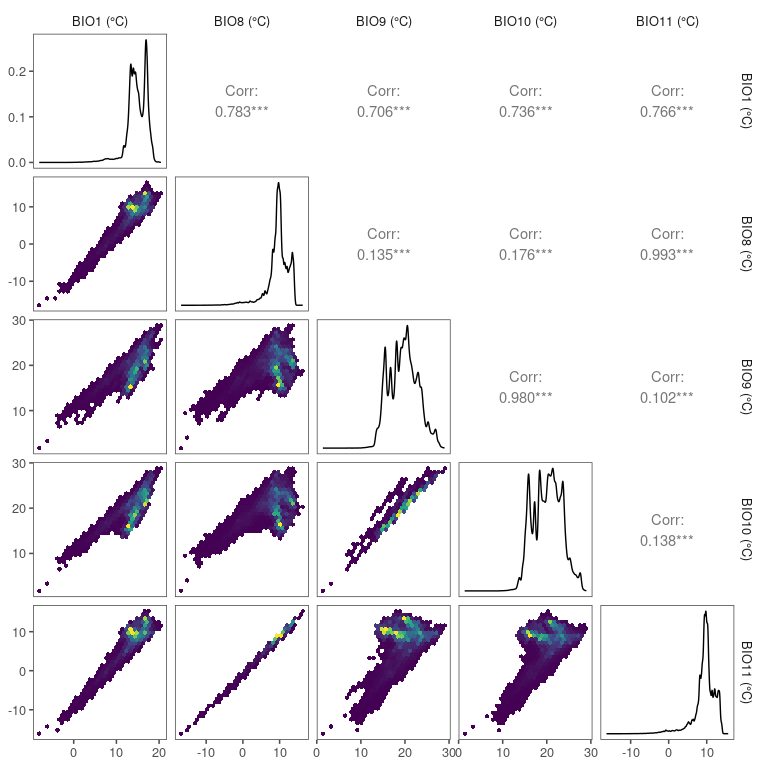

```r
dat_trait_bioclim <- read_individual_trait(path_trait = "alldata/intermediate/climate-niche/gbif-chelsa_full.rds")
gg_bioclim_tmp <- plot_bioclim(dat_trait_bioclim, var = "tmp")
gg_bioclim_tmp
```

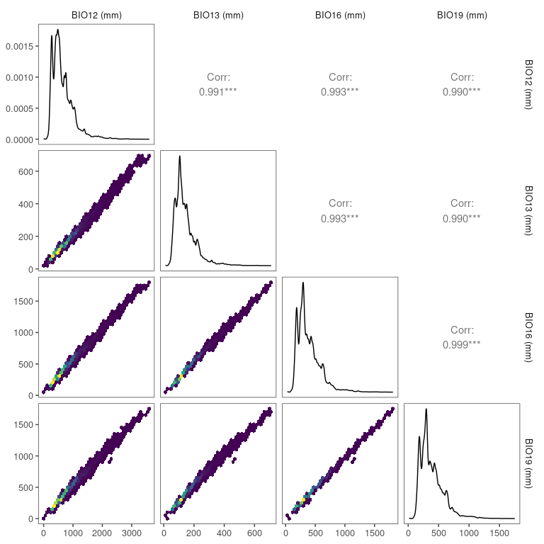

```r
gg_bioclim_ppt <- plot_bioclim(dat_trait_bioclim, var = "ppt")
gg_bioclim_ppt
```

Compare estimates of species climate niche using different summary statistics.

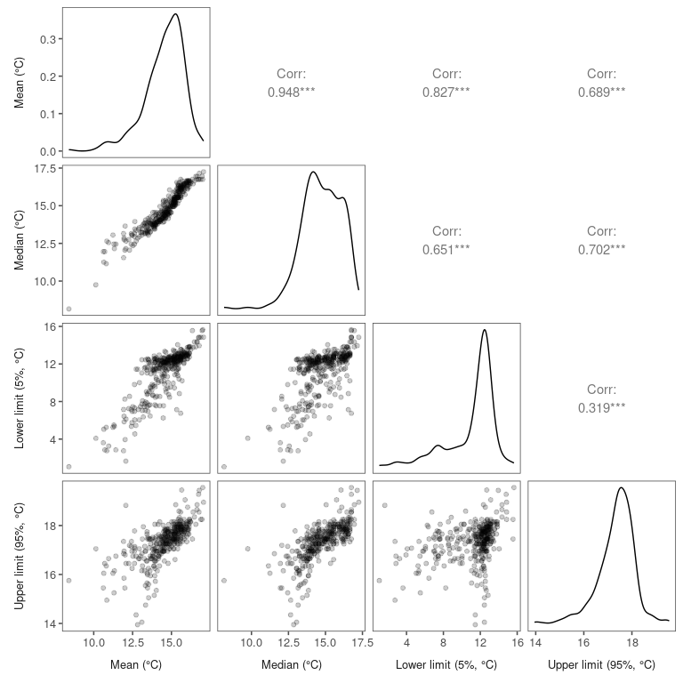

```r
gg_niche_stat_tmp <- plot_niche_stat(dat_niche, var = "tmp")
gg_niche_stat_tmp
```

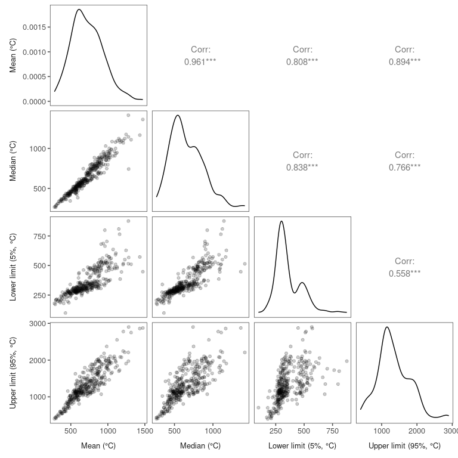

```r
gg_niche_stat_ppt <- plot_niche_stat(dat_niche, var = "ppt")
gg_niche_stat_ppt
```

Compare estimates of species climate niche by spatial thinning occurrence records.

```r
path_occ_thin <- cal_thin_occ(dat_occ = dat_occ$gbif) # slow
```

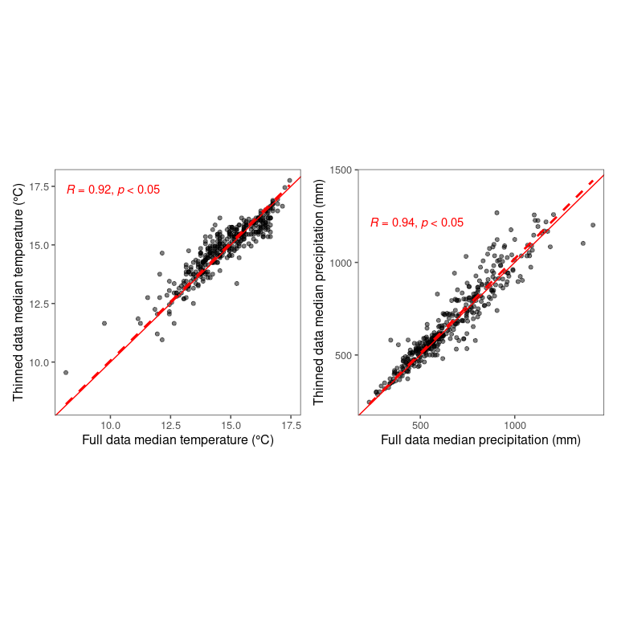

```r
dat_trait_thin <- calc_trait_thin(path_occ_thin = NULL, dat_trait)
dat_niche_thin <- calc_species_niche(dat_trait_thin, add_dummy = T)
gg_niche_thin <- plot_niche_thin(dat_niche, dat_niche_thin)
gg_niche_thin
```

Output figures and R data files.

```r
save_figure(out = list(
  biogeography = gg_biogeography,
  guild_niche = gg_guild_niche,
  niche = gg_niche$combined,
  niche_cool = gg_individual_trait_species_niche_cool,
  niche_warm = gg_individual_trait_species_niche_warm,
  clim_source = gg_climate_source,
  bioclim_tmp = gg_bioclim_tmp,
  bioclim_ppt = gg_bioclim_ppt,
  niche_stat_tmp = gg_niche_stat_tmp,
  niche_stat_ppt = gg_niche_stat_ppt,
  niche_thin = gg_niche_thin
))
save_rda(out = list(dat_occ, dat_trait, dat_niche))
```